# Projeto Integrador - Exercicio 03

Adelvan Lima

```r
library(readr)
library(descr)
library(dplyr)
```

Olá pessoal! Vamos praticar um pouco as análises preliminares sobre um banco de dados. Hoje, vamos trabalhar com o banco de dados do ENADE. O banco de dados que vamos usar é uma amostra aleatória de apenas 10 mil alunos. Usaremos essa amostra para facilitar um pouco o uso de memória em nossas máquinas. A versão original dos dados, bem como o dicionário de variáveis, pode ser obtido em http://portal.inep.gov.br/microdados.

Para ler o banco de dados direto da internet, use o comando:

```r
library(readr)
enade14 <- read_csv2("https://raw.githubusercontent.com/neylsoncrepalde/introducao_ao_r/master/dados/enade_2014_amostra.csv")
```

Este exercício já deve ser entregue num documento do tipo RMarkdown. Você deve apresentar o arquivo .Rmd e o html gerado! Imagina um cliente olhando para uma apresentação caprichada dessas!!!!! S2

## 1. Mostre com um comando e usando um gráfico a distribuição das idades dessa amostra de alunos que fizeram ENADE em 2014. Comente o resultado.

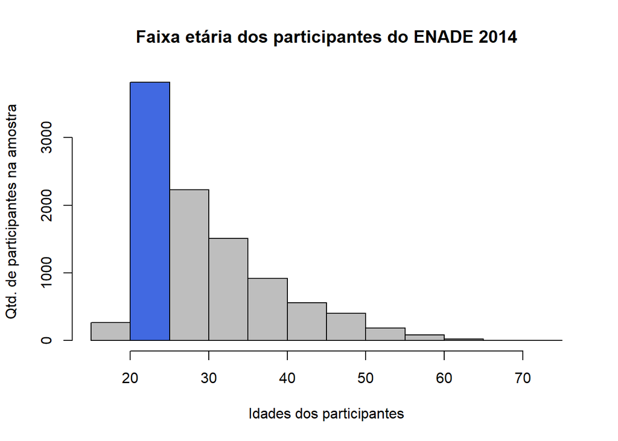

```r
hist(enade14$nu_idade,
     main = "Faixa etária dos participantes do ENADE 2014",
     xlab = "Idades dos participantes",
     ylab = "Qtd. de participantes na amostra",
     col = c("grey", "#4169E1", "grey", "grey", "grey", "grey", "grey", "grey", "grey", "grey"))
```

A partir da amostra, percebe-se que a presença de participantes entre 20 e 25 anos é maior do que as outra faixas etárias.

## 2. Monte uma tabela exibindo as porcentagens e os valores absolutos das proporções de alunos por COR/RAÇA. O descobrimos sobre isso?

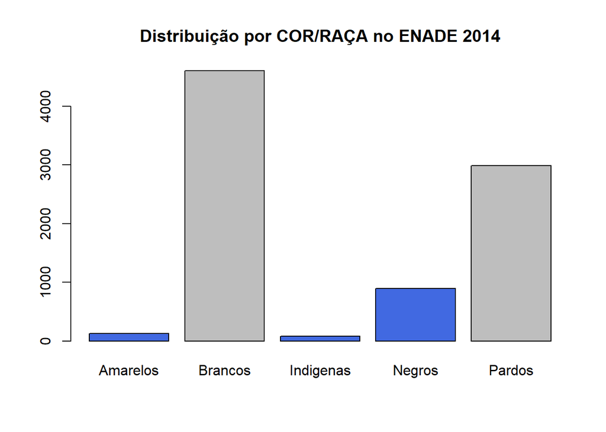

```
## cor_raca[!is.na(cor_raca)]
##           Frequência Percentual
## Amarelos         129     1.4838
## Brancos         4606    52.9791
## Indigenas         78     0.8972
## Negros           893    10.2715
## Pardos          2988    34.3685
## Total           8694   100.0000
```

```r
cor_raca <- enade14$qe_i2
cor_raca[cor_raca == "a"] <- "Brancos"
cor_raca[cor_raca == "b"] <- "Negros"
cor_raca[cor_raca == "c"] <- "Pardos"
cor_raca[cor_raca == "d"] <- "Amarelos"
cor_raca[cor_raca == "e"] <- "Indigenas"

freq(cor_raca[!is.na(cor_raca)],
     col= c("#4169E1", "grey", "#4169E1", "#4169E1", "grey"),
     main = "Distribuição por COR/RAÇA no ENADE 2014")
```

Podemos perceber que amarelos, indigenas e negros, representados neste gráfico pela cor azul, foram minorias durante a aplicação do ENADE 2014.

## 3. Apresente a proporção de alunos casados e solteiros. Atenção, queremos apenas CASADOS e SOLTEIROS. Exclua de sua análise os alunos que tiverem outro tipo de estado civil.

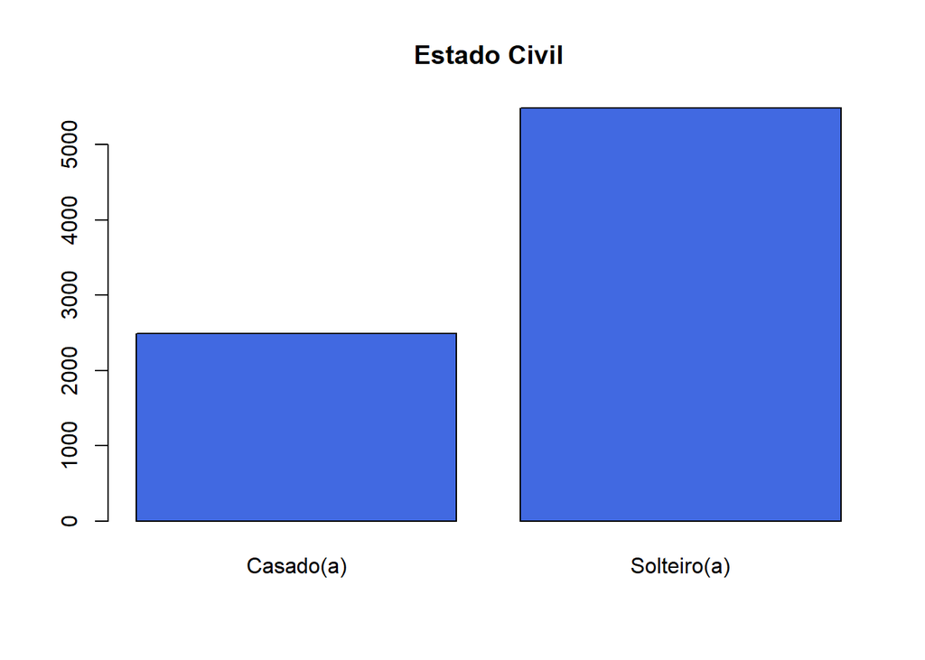

```
## enade14$estado_civil[!is.na(enade14$estado_civil)]
##             Frequência Percentual
## Casado(a)         2486      31.18
## Solteiro(a)       5487      68.82
## Total             7973     100.00
```

```r
enade14$estado_civil <- enade14$qe_i1

enade14$estado_civil[enade14$estado_civil == "a"] <- "Solteiro(a)"
enade14$estado_civil[enade14$estado_civil == "b"] <- "Casado(a)"
enade14$estado_civil[enade14$estado_civil == "c"] <- NA
enade14$estado_civil[enade14$estado_civil == "d"] <- NA
enade14$estado_civil[enade14$estado_civil == "e"] <- NA

freq(enade14$estado_civil[!is.na(enade14$estado_civil)],
     col= "#4169E1",
     main = "Estado Civil")
```

## 4. Apresente estatísticas descritivas sobre a nota geral dos alunos no Enade. Apresente também a informação em um gráfico. Qual é o gráfico mais adequado para a visualização desta variável? Por quê? Comente sobre a nota geral. Os alunos parecem ter, no geral, um bom desempenho ou um mal desempenho?

```r
summary(enade14$nt_ger)
```

```
##    Min. 1st Qu.  Median    Mean 3rd Qu.    Max.    NA's
##     0.0   292.0   414.0   399.6   528.0   943.0    1724
```

A média dos alunos ficou em torno de 399.6 que é aproximadamente 42% da nota maxima obtida que foi de 943.0, isso pode significar que no geral, o desempenho dos alunos foi regular.

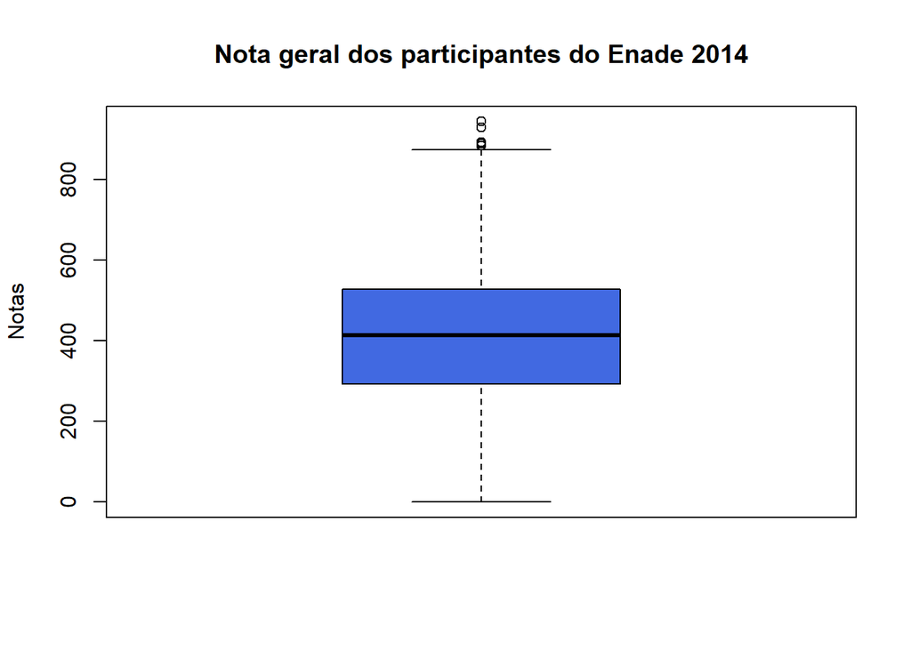

```r
boxplot(enade14$nt_ger,
        col = "#4169E1",
        main = "Nota geral dos participantes do Enade 2014",
        ylab = "Notas")
```

O Boxplot é o gráfico mais adequado pois é uma maneira simples e rápida de ter uma ideia da distribuição dos dados.

## 5. Crie uma variável binária chamada `PUBLICA`. Nessa variável, você deve marcar 1 se a universidade em que o aluno estudou foi pública e 0 se foi privada. **ATENÇÃO**: existe uma variável com a categoria administrativa da IES mas ela possui várias subclassificações. É preciso que você crie outra variável com as categorias corretas.

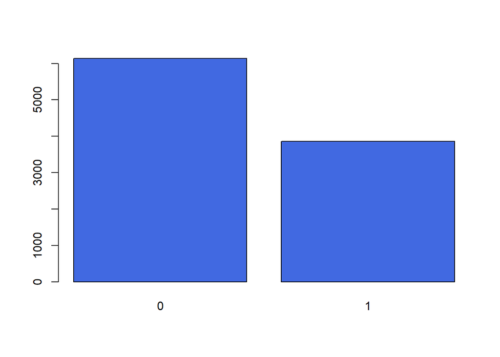

```
## enade14$PUBLICA
##       Frequência Percentual
## 0           6139      61.39
## 1           3861      38.61
## Total      10000     100.00
```

```r
enade14$PUBLICA = enade14$co_catad

enade14$PUBLICA[enade14$PUBLICA == 93] = 1
enade14$PUBLICA[enade14$PUBLICA == 116] = 1
enade14$PUBLICA[enade14$PUBLICA == 118] = 0
enade14$PUBLICA[enade14$PUBLICA == 121] = 0
enade14$PUBLICA[enade14$PUBLICA == 10001] = 1
enade14$PUBLICA[enade14$PUBLICA == 10002] = 1
enade14$PUBLICA[enade14$PUBLICA == 10003] = 1
enade14$PUBLICA[enade14$PUBLICA == 10004] = 0
enade14$PUBLICA[enade14$PUBLICA == 10005] = 0
enade14$PUBLICA[enade14$PUBLICA == 10006] = 0
enade14$PUBLICA[enade14$PUBLICA == 10007] = 0
enade14$PUBLICA[enade14$PUBLICA == 10008] = 0
enade14$PUBLICA[enade14$PUBLICA == 10009] = 0

freq(enade14$PUBLICA,
     col= "#4169E1")
```

## 6. Mostre a distribuição da renda para os alunos do ENADE 2014. Mostre também a distribuição de renda apenas para os alunos das escolas públicas e das escolas privadas.

```r
distribuicao_renda <- enade14$qe_i8
distribuicao_renda[distribuicao_renda == "a"] <- "Até 1,5 salário mínimo"
distribuicao_renda[distribuicao_renda == "b"] <- "De 1,5 a 3 salários mínimos"
distribuicao_renda[distribuicao_renda == "c"] <- "De 3 a 4,5 salários mínimos"
distribuicao_renda[distribuicao_renda == "d"] <- "De 4,5 a 6 salários mínimos"
distribuicao_renda[distribuicao_renda == "e"] <- "De 6 a 10 salários mínimos"
distribuicao_renda[distribuicao_renda == "f"] <- "De 10 a 30 salários mínimos"
distribuicao_renda[distribuicao_renda == "g"] <- "Acima de 30 salários mínimos"
```

### Distribuição da renda para os alunos do ENADE 2014

```r
# DISTRIBUIÇÃO DE RENDA
freq(distribuicao_renda[!is.na(distribuicao_renda)], plot = FALSE)
```

```
## distribuicao_renda[!is.na(distribuicao_renda)]
##                              Frequência Percentual
## Acima de 30 salários mínimos         82     0.9432
## Até 1,5 salário mínimo             1595    18.3460
## De 1,5 a 3 salários mínimos        2445    28.1228
## De 10 a 30 salários mínimos         631     7.2579
## De 3 a 4,5 salários mínimos        1753    20.1633
## De 4,5 a 6 salários mínimos        1049    12.0658
## De 6 a 10 salários mínimos         1139    13.1010
## Total                              8694   100.0000
```

### Distribuição de renda dos alunos do ENADE 2014 tendo como referência as Escolas Publicas

```r
freq(distribuicao_renda[enade14$PUBLICA == 1], plot = FALSE)
```

```
## distribuicao_renda[enade14$PUBLICA == 1]
##                              Frequência Percentual Perc. Válido
## Acima de 30 salários mínimos         32     0.8288       0.9552
## Até 1,5 salário mínimo              731    18.9329      21.8209
## De 1,5 a 3 salários mínimos         943    24.4237      28.1493
## De 10 a 30 salários mínimos         221     5.7239       6.5970
## De 3 a 4,5 salários mínimos         618    16.0062      18.4478
## De 4,5 a 6 salários mínimos         369     9.5571      11.0149
## De 6 a 10 salários mínimos          436    11.2924      13.0149
## NA's                                511    13.2349
## Total                              3861   100.0000     100.0000
```

### Distribuição de renda dos alunos do ENADE 2014 tendo como referência as Escolas Privadas

```r
# ESCOLA PRIVADA
freq(distribuicao_renda[enade14$PUBLICA == 0], plot = FALSE)
```

```
## distribuicao_renda[enade14$PUBLICA == 0]
##                              Frequência Percentual Perc. Válido
## Acima de 30 salários mínimos         50     0.8145       0.9356
## Até 1,5 salário mínimo              864    14.0740      16.1677
## De 1,5 a 3 salários mínimos        1502    24.4665      28.1063
## De 10 a 30 salários mínimos         410     6.6786       7.6722
## De 3 a 4,5 salários mínimos        1135    18.4884      21.2388
## De 4,5 a 6 salários mínimos         680    11.0767      12.7246
## De 6 a 10 salários mínimos          703    11.4514      13.1549
## NA's                                795    12.9500
## Total                              6139   100.0000     100.0000
```

## 7. Mostre agora a nota geral dos alunos das faculdades públicas e dos alunos das faculdades privadas. O que você acha desses dados?

```r
# Média da nota geral dos alunos de faculdades públicas:
nota.geral_faculdade.publica <- enade14$nt_ger[enade14$PUBLICA == 1]
mean(nota.geral_faculdade.publica, na.rm = T)
```

```
## [1] 411.9
```

```r
# Média da nota geral dos alunos de faculdades privadas:
nota.geral_faculdade.privada <- enade14$nt_ger[enade14$PUBLICA == 0]
mean(nota.geral_faculdade.privada, na.rm = T)
```

```
## [1] 391.9547
```

A diferença de notas gerais entre as faculdades públicas e as faculdades privadas foi de 19,94 pontos, o que pode signficar que embora melhor, o desempenho médio das universidades públicas não está muito longe do desempenho obtido pelas faculdades particulares.

## 8. **BÔNUS**: Existe um teste estatístico para verificar se a média da nota geral desta amostra dos alunos que fizeram ENADE pode ser inferida para toda a população? Faça o teste e apresente os resultados. Qual é o intervalo de confiança do teste?

```r
# Futuramente, pretendo voltar neste desafio e atualizá-lo.
```

## 9. **BÔNUS**: Existe um teste estatístico para verificar se a diferença entre as notas dos alunos das universidades públicas e dos alunos das universidades privadas é estatisticamente significante? Faça o teste e apresente os resultados.

```r
# Futuramente, pretendo voltar neste desafio e atualizá-lo.
```